# Joel Swenson_breast_cancer

Below is an example of some code I wrote for a data challenge using a public and well-known dataset.

## Breast Cancer Cell Detection

Develop a model that predicts whether a biopsied breast tumor is benign (not harmful) or malignant (cancerous), given a set of attributes about the tumor.

The dataset consists of 699 cells for which you have the following features:

Sample code number: id number Clump Thickness: 1 - 10 Uniformity of Cell Size: 1 - 10 Uniformity of Cell Shape: 1 - 10 Marginal Adhesion: 1 - 10 Single Epithelial Cell Size: 1 - 10 Bare Nuclei: 1 - 10 Bland Chromatin: 1 - 10 Normal Nucleoli: 1 - 10 Mitoses: 1 - 10

Class: (2 for benign, 4 for malignant)

The dataset is also available here: https://archive.ics.uci.edu/ml/machine-learning-databases/breast-cancer-wisconsin/breast-cancer-wisconsin.data I hunted down the original paper here: https://www.ncbi.nlm.nih.gov/pmc/articles/PMC55130/pdf/pnas01048-0130.pdf

#### Overal goals

- I need to build a binary classifer.
- I will optimize for recall since this seems to be a screening tool (i.e. I would suggest this product be run as a first pass to prioritize which samples a physician should look at).
- I will extract feature importance and do feature reduction to reduce time and money to collect each feature
- Load and Inspect Data
- Clean Data
- Visualize Data
- Set-up a Pipeline for Preprocessing and Modeling
  - Define Helper Function for Evaluating Model Performance
  - Optimize Imputation
- Find the Best Predictive Model
  - Random Forest with Hyperparameter Search
  - Logistic Regression with Hyperparameter Search
- Feature Importance
- Build a Model with Reduced Features
  - Create Custom Class to Transform Data
- Summary of All Models

```python
import sklearn
import numpy as np
import pandas as pd
import seaborn as sns
import matplotlib.pylab as plt
%matplotlib inline
```

# Load and inspect the data

```python
data = pd.read_csv("breast-cancer-wisconsin.csv",names=['id','thickness','uniformity_size','uniformity_shape','marg_adhesion','se_size','bare_nuclei','bland_chromatin','normal_nucleoli','mitoses','class'])
```

```python
data.head()
```

|  | id | thickness | uniformity_size | uniformity_shape | marg_adhesion | se_size | bare_nuclei | bland_chromatin | normal_nucleoli | mitoses | class |
| --- | --- | --- | --- | --- | --- | --- | --- | --- | --- | --- | --- |
| 0 | 1000025 | 5 | 1 | 1 | 1 | 2 | 1 | 3 | 1 | 1 | 2 |
| 1 | 1002945 | 5 | 4 | 4 | 5 | 7 | 10 | 3 | 2 | 1 | 2 |
| 2 | 1015425 | 3 | 1 | 1 | 1 | 2 | 2 | 3 | 1 | 1 | 2 |
| 3 | 1016277 | 6 | 8 | 8 | 1 | 3 | 4 | 3 | 7 | 1 | 2 |
| 4 | 1017023 | 4 | 1 | 1 | 3 | 2 | 1 | 3 | 1 | 1 | 2 |

```python
data.isna().sum()
```

```
id                  0
thickness           0
uniformity_size     0
uniformity_shape    0
marg_adhesion       0
se_size             0
bare_nuclei         0
bland_chromatin     0
normal_nucleoli     0
mitoses             0
class               0
dtype: int64
```

There are no NaNs or Null values, at least. But it's worth looking a bit more carefully for missing data as well by chekcing the min, max, median, and type of each feature as well.

```python
#[print(data[col].describe()) for col in data]
# Not run but is a way to essentially get the same output as describe and info
```

```python
data.describe(include = "all")
```

|  | id | thickness | uniformity_size | uniformity_shape | marg_adhesion | se_size | bare_nuclei | bland_chromatin | normal_nucleoli | mitoses | class |
| --- | --- | --- | --- | --- | --- | --- | --- | --- | --- | --- | --- |
| count | 6.990000e+02 | 699.000000 | 699.000000 | 699.000000 | 699.000000 | 699.000000 | 699 | 699.000000 | 699.000000 | 699.000000 | 699.000000 |
| unique | NaN | NaN | NaN | NaN | NaN | NaN | 11 | NaN | NaN | NaN | NaN |
| top | NaN | NaN | NaN | NaN | NaN | NaN | 1 | NaN | NaN | NaN | NaN |
| freq | NaN | NaN | NaN | NaN | NaN | NaN | 402 | NaN | NaN | NaN | NaN |
| mean | 1.071704e+06 | 4.417740 | 3.134478 | 3.207439 | 2.806867 | 3.216023 | NaN | 3.437768 | 2.866953 | 1.589413 | 2.689557 |
| std | 6.170957e+05 | 2.815741 | 3.051459 | 2.971913 | 2.855379 | 2.214300 | NaN | 2.438364 | 3.053634 | 1.715078 | 0.951273 |
| min | 6.163400e+04 | 1.000000 | 1.000000 | 1.000000 | 1.000000 | 1.000000 | NaN | 1.000000 | 1.000000 | 1.000000 | 2.000000 |
| 25% | 8.706885e+05 | 2.000000 | 1.000000 | 1.000000 | 1.000000 | 2.000000 | NaN | 2.000000 | 1.000000 | 1.000000 | 2.000000 |
| 50% | 1.171710e+06 | 4.000000 | 1.000000 | 1.000000 | 1.000000 | 2.000000 | NaN | 3.000000 | 1.000000 | 1.000000 | 2.000000 |
| 75% | 1.238298e+06 | 6.000000 | 5.000000 | 5.000000 | 4.000000 | 4.000000 | NaN | 5.000000 | 4.000000 | 1.000000 | 4.000000 |
| max | 1.345435e+07 | 10.000000 | 10.000000 | 10.000000 | 10.000000 | 10.000000 | NaN | 10.000000 | 10.000000 | 10.000000 | 4.000000 |

Something is going on with bare_nuclei, will need to look at that more

```python
data.info()
```

```
<class 'pandas.core.frame.DataFrame'>
RangeIndex: 699 entries, 0 to 698
Data columns (total 11 columns):
 #   Column            Non-Null Count  Dtype
---  ------            --------------  -----
 0   id                699 non-null    int64
 1   thickness         699 non-null    int64
 2   uniformity_size   699 non-null    int64
 3   uniformity_shape  699 non-null    int64
 4   marg_adhesion     699 non-null    int64
 5   se_size           699 non-null    int64
 6   bare_nuclei       699 non-null    object
 7   bland_chromatin   699 non-null    int64
 8   normal_nucleoli   699 non-null    int64
 9   mitoses           699 non-null    int64
 10  class             699 non-null    int64
dtypes: int64(10), object(1)
memory usage: 60.2+ KB
```

```python
# see what values are in bare_nuclei
print(data.bare_nuclei.unique())
```

```
['1' '10' '2' '4' '3' '9' '7' '?' '5' '8' '6']
```

There is a '?' value that will need to be dealt with

```python
# how many '?'s are there?
data[data['bare_nuclei']=='?'].count()
```

```
id                  16
thickness           16
uniformity_size     16
uniformity_shape    16
marg_adhesion       16
se_size             16
bare_nuclei         16
bland_chromatin     16
normal_nucleoli     16
mitoses             16
class               16
dtype: int64
```

```python
# see which rows have '?' to get some intuition for if its important and/or random
data[data['bare_nuclei']=='?']
```

|  | id | thickness | uniformity_size | uniformity_shape | marg_adhesion | se_size | bare_nuclei | bland_chromatin | normal_nucleoli | mitoses | class |
| --- | --- | --- | --- | --- | --- | --- | --- | --- | --- | --- | --- |
| 23 | 1057013 | 8 | 4 | 5 | 1 | 2 | ? | 7 | 3 | 1 | 4 |
| 40 | 1096800 | 6 | 6 | 6 | 9 | 6 | ? | 7 | 8 | 1 | 2 |
| 139 | 1183246 | 1 | 1 | 1 | 1 | 1 | ? | 2 | 1 | 1 | 2 |
| 145 | 1184840 | 1 | 1 | 3 | 1 | 2 | ? | 2 | 1 | 1 | 2 |
| 158 | 1193683 | 1 | 1 | 2 | 1 | 3 | ? | 1 | 1 | 1 | 2 |
| 164 | 1197510 | 5 | 1 | 1 | 1 | 2 | ? | 3 | 1 | 1 | 2 |
| 235 | 1241232 | 3 | 1 | 4 | 1 | 2 | ? | 3 | 1 | 1 | 2 |
| 249 | 169356 | 3 | 1 | 1 | 1 | 2 | ? | 3 | 1 | 1 | 2 |
| 275 | 432809 | 3 | 1 | 3 | 1 | 2 | ? | 2 | 1 | 1 | 2 |
| 292 | 563649 | 8 | 8 | 8 | 1 | 2 | ? | 6 | 10 | 1 | 4 |
| 294 | 606140 | 1 | 1 | 1 | 1 | 2 | ? | 2 | 1 | 1 | 2 |
| 297 | 61634 | 5 | 4 | 3 | 1 | 2 | ? | 2 | 3 | 1 | 2 |
| 315 | 704168 | 4 | 6 | 5 | 6 | 7 | ? | 4 | 9 | 1 | 2 |
| 321 | 733639 | 3 | 1 | 1 | 1 | 2 | ? | 3 | 1 | 1 | 2 |
| 411 | 1238464 | 1 | 1 | 1 | 1 | 1 | ? | 2 | 1 | 1 | 2 |
| 617 | 1057067 | 1 | 1 | 1 | 1 | 1 | ? | 1 | 1 | 1 | 2 |

```python
missing_data_rows = data['bare_nuclei'] == '?' # boolean 1D vector denoting which rows have '?' in bare_nuclei column
```

```python
print("Benign is ", str(100*sum(data['class'] == 2)/len(data.index)), "%", "of total labels")
```

```
Benign is  65.52217453505007 % of total labels
```

```python
print("Malignant is ", str(100*sum(data['class'] == 4)/len(data.index)), "%", "of total labels")
```

```
Malignant is  34.47782546494993 % of total labels
```

[Note that we have a slight class imbalance problem. In my experience classes are likely balanced enough to not be a problem.]

```python
print("Missing X percentage of overall benign labels: ", str(100*sum(data[missing_data_rows]['class']==2)/sum(data['class'] == 2)))
```

```
Missing X percentage of overall benign labels:  3.056768558951965
```

```python
print("Missing X percentage of overall malignant labels: ", str(100*sum(data[missing_data_rows]['class']==4)/sum(data['class'] == 4)))
```

```
Missing X percentage of overall malignant labels:  0.8298755186721992
```

```python
print("X percentage of missing samples are malignant: ", str(100*sum(data[missing_data_rows]['class']==4)/len(data[missing_data_rows].index)))
```

```
X percentage of missing samples are malignant:  12.5
```

Benign was 65.5% of total labels but 87.5% of missing samples were benign. So majority of missing samples are benign but not the same perc if missing-ness was random.

We are missing such a small amount (even though the missing-ness doesn't appear random) I would normally just drop the missing values....but since this is a fun exercise lets impute! There are various ways to do this: sklearn has several methods...KNNimputter seems like it would work well here since its multi-dimensional data and doesn't appear to be missing at random.

## Clean the data a bit

```python
# Convert classes in data from 2 (benign) and 4 (malignant) to 0 (benign) and 1 (malignant)
data = data.replace({'class':{2:0,4:1}})
```

```python
# Drop ID column
data = data.drop(columns='id')
```

```python
# Replace '?'s with NaNs
data = data.replace('?',np.NaN)
```

## Visualize the data a bit

```python
# Remember '0' is benign and '1' is malignant...I won't change the labels
# due to the figure being huge already
# sns.pairplot(data, hue="class", diag_kind="hist")
# plt.show()
```

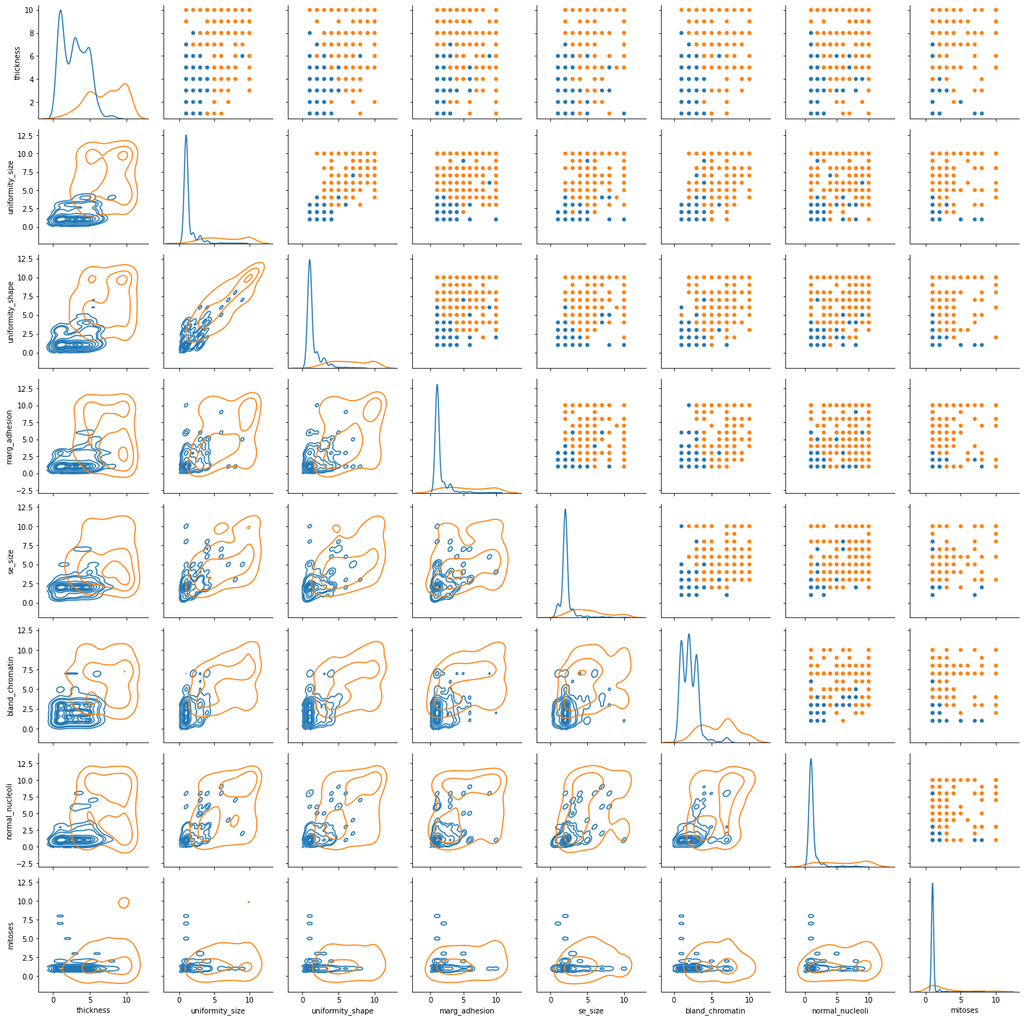

```python
# Remember '0' is benign and '1' is malignant...I won't change the labels
# due to the figure being huge already.
# Benign is blue, Malignant is organge.

kde_pp = sns.PairGrid(data, diag_sharey=False, hue="class")
kde_pp.map_upper(sns.scatterplot)
kde_pp.map_lower(sns.kdeplot)
kde_pp.map_diag(sns.kdeplot)
plt.show()
```

There is good separation between the classes and some structure in the data. Seems likely we will be able to build a decent classifier.

Uniformity_size and uniformity_shape seem to be highly correlated...lets inspect more below

### Look at the correlation between features

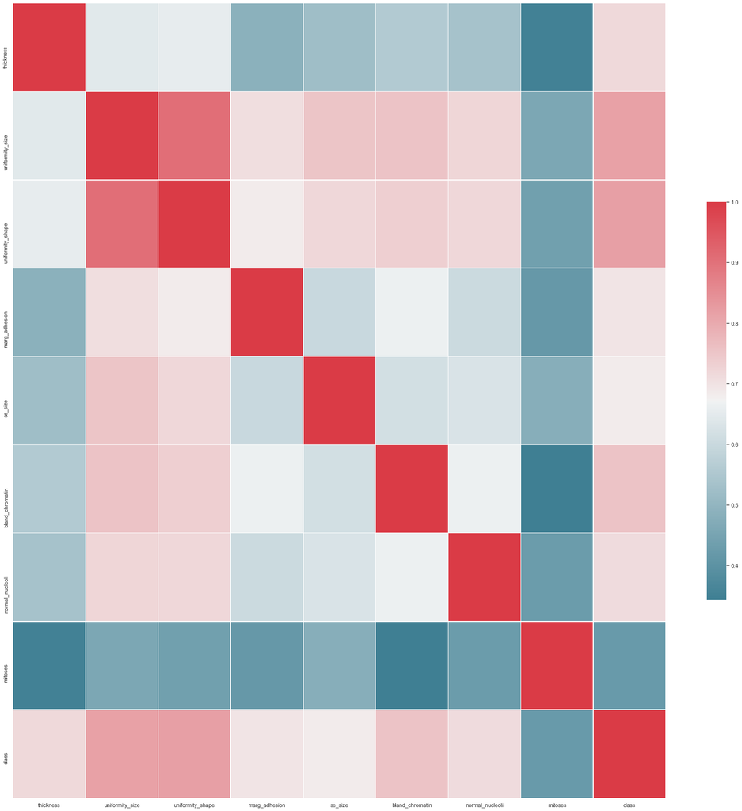

```python
sns.set(style="white")
# Compute the correlation matrix
corr = data.corr()

# Set up the matplotlib figure
f, ax = plt.subplots(figsize=(30, 30))

# Generate a custom diverging colormap
cmap = sns.diverging_palette(220, 10, as_cmap=True)

# Draw the heatmap with the mask and correct aspect ratio
sns.heatmap(corr, cmap=cmap,
           linewidths=.5, cbar_kws={"shrink": .5}, ax=ax)
plt.show()
```

Uniformity_size and uniformity_shape are highly correlated which I should keep in mind for modeling choices, feature elimination, etc

## Set-up a Pipeline for Processing and modeling: imputing missing data, scaling, modeling

See if I can build a simple model and then refine it

```python
from sklearn.impute import KNNImputer
from sklearn.compose import ColumnTransformer
from sklearn.preprocessing import RobustScaler
from sklearn.pipeline import Pipeline
from sklearn.model_selection import train_test_split
from sklearn.linear_model import LogisticRegression
from sklearn.naive_bayes import MultinomialNB
from sklearn.metrics import classification_report
from sklearn.metrics import plot_confusion_matrix
```

```python
# Create the pipeline
pl_steps = [('KNN imputer', KNNImputer(n_neighbors=3,weights='distance')),
                ('robust scaler', RobustScaler()),
                ('lr', LogisticRegression(random_state=52))]
pipeline = Pipeline(pl_steps)
```

##### Split the data for training and validation

```python
X = data.drop(['class'], axis=1)
y = data['class']
```

```python
#create training and test set
dict_of_parameters = {'test_size':0.35,'random_state':42}
X_train, X_test, y_train, y_test = train_test_split(X, y, **dict_of_parameters)
```

```python
pipeline.fit(X_train,y_train)
```

```
Pipeline(steps=[('KNN imputer', KNNImputer(n_neighbors=3, weights='distance')),
                ('robust scaler', RobustScaler()),
                ('lr', LogisticRegression(random_state=52))])
```

```python
def predict_and_eval_classification_perf(model_estimator, X_test, y_test, class_labels_lists, descriptive_text):
    """
    Calls predict on an estimator (i.e. model_estimator) like a fit pipeline oject, displays and saves common classification performance metrics
    To_do: implement boolean to run silently; add more options for graphing (e.g. labelling classes)

    Parameters
    ----------
    model_estimator: A fit model
    X_test (pandas.core.frame.DataFrame): Test data for evaluating model performance
    y_test (pandas.core.frame.DataFrame): Test labels for evaluating model performance
    class_labels_lists (list of lists): [[L1],[L2]]
        L1: array-like of shape (n_classes,)
                List of labels to index the matrix. This may be used to reorder or
                select a subset of labels. If `None` is given, those that appear at
                least once in `y_true` or `y_pred` are used in sorted order.
        L2: display_labels : array-like of shape (n_classes,)
                Target names used for plotting. By default, `labels` will be used if
                it is defined, otherwise the unique labels of `y_true` and `y_pred`
                will be used.
    decriptive_text (str): Optional descriptive text to add to graph titles
    bool_print -- not implemented yet

    Returns
    -------
    model_prediction: a numpy array generated by "predict"
    report: a classification report
    cm: a confusion matrix plot


    """
    # Fit model
    model_prediction = model_estimator.predict(X_test)

    # Build, display, and save classification report
    report = classification_report(y_test, model_prediction)
    print(report)

    # Build, display, and save classification report
    cm = plot_confusion_matrix(model_estimator, X_test, y_test, labels=class_labels_lists[0], display_labels=class_labels_lists[1],
                    cmap=plt.cm.Blues)
    cm.ax_.set_title("Confusion Matrix: " + descriptive_text)
    plt.show()
    return model_prediction, report, cm
```

```
              precision    recall  f1-score   support

           0       0.96      0.99      0.98       164
           1       0.99      0.93      0.96        81

    accuracy                           0.97       245
   macro avg       0.98      0.96      0.97       245
weighted avg       0.97      0.97      0.97       245
```

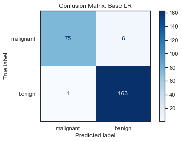

```python
lr_prediction, lr_report, lr_cm =\
    predict_and_eval_classification_perf(pipeline, X_test, y_test, [[1,0],['malignant','benign']], "Base LR")
```

### Optimize imputation: Choose the correct k for KNN

```python
from sklearn.model_selection import cross_val_score
from sklearn.model_selection import RepeatedStratifiedKFold
from numpy import mean
from numpy import std
from matplotlib import pyplot
```

```python
# Find the best k in KNN. Note that lower k will have more noise and higher k will approximate
# just imputing with mean.
# Modified from https://machinelearningmastery.com/knn-imputation-for-missing-values-in-machine-learning/
results = list()
ks = [str(i) for i in [1,3,5,7,9,11,311]]
for k in ks:
    # create the pipeline
    pl_steps = [('KNN imputer', KNNImputer(n_neighbors=int(k),weights='distance')),
                ('robust scaler', RobustScaler()),
                ('lr', LogisticRegression(random_state=52))]
    KNN_pipeline = Pipeline(pl_steps)
    # evaluate the model using cross-validation
    cv = RepeatedStratifiedKFold(n_splits=10, n_repeats=5, random_state=99)
    scores = cross_val_score(KNN_pipeline, X_train, y_train, scoring='recall', cv=cv, n_jobs=-1)
    # store results
    results.append(scores)
    print('>%s %.3f (%.3f)' % (k, mean(scores), std(scores)))
```

```
>1 0.943 (0.050)
>3 0.944 (0.050)
>5 0.944 (0.049)
>7 0.944 (0.049)
>9 0.944 (0.049)
>11 0.944 (0.049)
>311 0.943 (0.048)
```

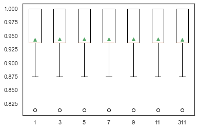

```python
# plot model performance for comparison
pyplot.boxplot(results, labels=ks, showmeans=True)
pyplot.show()
```

It seems like the size of k doesn't have a big impact on model performance. I wonder if KNNImputation is actually any better than a more naive approach like using the mean....based on the above results probably only slightly and might not be robustly different. I will test if KNNImputation is actually any better than a more naive approach next.

### Is KNN imputation better than replacing with mean?

```python
from sklearn.impute import SimpleImputer
```

```python
# Create a new with no imputation pipeline
simple_imp_pl_steps = [('mean imputation', SimpleImputer(missing_values=np.NaN,strategy='mean')),
                ('robust scaler', RobustScaler()),
                ('lr', LogisticRegression(random_state=52))]
simple_imp_pipeline = Pipeline(simple_imp_pl_steps)
```

```python
simple_imp_pipeline.fit(X_train,y_train)
```

```
Pipeline(steps=[('mean imputation', SimpleImputer()),
                ('robust scaler', RobustScaler()),
                ('lr', LogisticRegression(random_state=52))])
```

```python
simple_imp_pipeline_prediction = simple_imp_pipeline.predict(X_test)
```

```python
# Mean "imputation" performance
print(classification_report(y_test,simple_imp_pipeline_prediction))
```

```
              precision    recall  f1-score   support

           0       0.96      0.99      0.98       164
           1       0.99      0.91      0.95        81

    accuracy                           0.97       245
   macro avg       0.97      0.95      0.96       245
weighted avg       0.97      0.97      0.97       245
```

```python
# KNN Imputation performance
print(lr_report)
```

```
              precision    recall  f1-score   support

           0       0.96      0.99      0.98       164
           1       0.99      0.93      0.96        81

    accuracy                           0.97       245
   macro avg       0.98      0.96      0.97       245
weighted avg       0.97      0.97      0.97       245
```

Compare mean imputation to KNNImputer and we see that KNNImputer is marginally better as recall for class 1 is 0.93 (not sure if this would hold up under multiple attempts). But since we are potentially talking about lives and KNN isn't computationally expensive with this size of data we will continue with it.

### Now lets find the best predictive model

```python
from sklearn.model_selection import GridSearchCV
from sklearn.model_selection import RandomizedSearchCV
from sklearn.ensemble import RandomForestClassifier
from pprint import pprint
```

#### Random Forest with hyperparameter search

```python
# Create the pipeline
rf_pl_steps = [('KNN imputer', KNNImputer(n_neighbors=3, weights='distance')),
                ('robust scaler', RobustScaler()),
                ('rf', RandomForestClassifier(random_state=52))]
rf_pipeline = Pipeline(rf_pl_steps)
```

```python
# Create hyperparameter search space

# np.linspace returns evenly spaced numbers over a specified interval to search number of trees in the forest
# According to the RandomizedSearchCV docs "It is highly recommended to use continuous distributions for continuous parameters."
# To-do: replace below search space with distributions
n_estimators = [int(x) for x in np.linspace(start = 20, stop = 200, num = 10)]
# Number of features to consider at every split
max_features = ['log2', 'sqrt'] # Note that in this instance since features are small they end up being very similar
# Maximum depth of the tree
max_depth = [int(x) for x in np.linspace(1, 45, num = 11)]
# Minimum number of samples required to split a node
min_samples_split = [3, 5, 10, 15]

# Create the random grid
random_grid = {'rf__n_estimators': n_estimators,
               'rf__max_features': max_features,
               'rf__max_depth': max_depth,
               'rf__min_samples_split': min_samples_split}
pprint(random_grid)
```

```
{'rf__max_depth': [1, 5, 9, 14, 18, 23, 27, 31, 36, 40, 45],
 'rf__max_features': ['log2', 'sqrt'],
 'rf__min_samples_split': [3, 5, 10, 15],
 'rf__n_estimators': [20, 40, 60, 80, 100, 120, 140, 160, 180, 200]}
```

```python
# To see all scorers uncomment below
#sorted(sklearn.metrics.SCORERS.keys())
```

I'll use recall as my scorer since I want to maximize positives that I find since this is a screening tool for a doctor.

```python
grid = RandomizedSearchCV(rf_pipeline,param_distributions=random_grid,\
                          n_iter = 10, cv = 10, verbose=2, random_state=42,\
                          n_jobs = -1, scoring='recall')
```

```python
grid.fit(X_train,y_train)
```

```
Fitting 10 folds for each of 10 candidates, totalling 100 fits
```

```
[Parallel(n_jobs=-1)]: Using backend LokyBackend with 4 concurrent workers.
[Parallel(n_jobs=-1)]: Done  56 tasks      | elapsed:    6.6s
[Parallel(n_jobs=-1)]: Done 100 out of 100 | elapsed:   12.5s finished
```

```
RandomizedSearchCV(cv=10,
                   estimator=Pipeline(steps=[('KNN imputer',
                                              KNNImputer(n_neighbors=3,
                                                         weights='distance')),
                                             ('robust scaler', RobustScaler()),
                                             ('rf',
                                              RandomForestClassifier(random_state=52))]),
                   n_jobs=-1,
                   param_distributions={'rf__max_depth': [1, 5, 9, 14, 18, 23,
                                                          27, 31, 36, 40, 45],
                                        'rf__max_features': ['log2', 'sqrt'],
                                        'rf__min_samples_split': [3, 5, 10, 15],
                                        'rf__n_estimators': [20, 40, 60, 80,
                                                             100, 120, 140, 160,
                                                             180, 200]},
                   random_state=42, scoring='recall', verbose=2)
```

```python
print("score = %3.2f" %(grid.score(X_test,y_test)))
```

```
score = 0.98
```

```python
print(grid.best_params_)
```

```
{'rf__n_estimators': 40, 'rf__min_samples_split': 5, 'rf__max_features': 'log2', 'rf__max_depth': 18}
```

```python
print(grid.best_estimator_)
```

```
Pipeline(steps=[('KNN imputer', KNNImputer(n_neighbors=3, weights='distance')),
                ('robust scaler', RobustScaler()),
                ('rf',
                 RandomForestClassifier(max_depth=18, max_features='log2',
                                        min_samples_split=5, n_estimators=40,
                                        random_state=52))])
```

```
              precision    recall  f1-score   support

           0       0.99      0.98      0.98       164
           1       0.95      0.98      0.96        81

    accuracy                           0.98       245
   macro avg       0.97      0.98      0.97       245
weighted avg       0.98      0.98      0.98       245
```

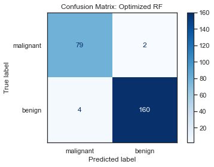

```python
# Evaluate model performance
rf_optm_prediction, rf_optm_report, rf_optm_cm =\
    predict_and_eval_classification_perf(grid, X_test, y_test, [[1,0],['malignant','benign']], "Optimized RF")
```

#### Logistic Regression with hyperparameter search

```python
# Create the pipeline
lr_pl_steps = [('KNN imputer', KNNImputer(n_neighbors=3, weights='distance')),
                ('robust scaler', RobustScaler()),
                ('lr', LogisticRegression(random_state=52))]
lr_pipeline = Pipeline(lr_pl_steps)
```

```python
# Create space to search lr hyperparamters

# According to the RandomizedSearchCV docs "It is highly recommended to use continuous distributions for continuous parameters."
# To-do: replace below search space with distributions
lr_hps = {'lr__C': [100, 10, 1.0, 0.1, 0.01]} # Regularization penalty is usually only one to matter
pprint(lr_hps)
```

```
{'lr__C': [100, 10, 1.0, 0.1, 0.01]}
```

```python
# To see all scorers uncomment below
#sorted(sklearn.metrics.SCORERS.keys())
```

I'll use recall as my scorer since I want to maximize positives that I find since this is a screening tool for a doctor.

```python
lr_grid = RandomizedSearchCV(lr_pipeline,param_distributions=lr_hps,\
                          n_iter = 10, cv = 10, verbose=2, random_state=42,\
                          n_jobs = -1, scoring='recall')
```

```python
lr_grid.fit(X_train,y_train)
```

```
Fitting 10 folds for each of 5 candidates, totalling 50 fits
```

```
RandomizedSearchCV(cv=10,
                   estimator=Pipeline(steps=[('KNN imputer',
                                              KNNImputer(n_neighbors=3,
                                                         weights='distance')),
                                             ('robust scaler', RobustScaler()),
                                             ('lr',
                                              LogisticRegression(random_state=52))]),
                   n_jobs=-1,
                   param_distributions={'lr__C': [100, 10, 1.0, 0.1, 0.01]},
                   random_state=42, scoring='recall', verbose=2)
```

```python
print("score = %3.2f" %(lr_grid.score(X_test,y_test)))
```

```
score = 0.90
```

```python
print(lr_grid.best_params_)
```

```
{'lr__C': 10}
```

```python
print(lr_grid.best_estimator_)
```

```
Pipeline(steps=[('KNN imputer', KNNImputer(n_neighbors=3, weights='distance')),
                ('robust scaler', RobustScaler()),
                ('lr', LogisticRegression(C=10, random_state=52))])
```

```
              precision    recall  f1-score   support

           0       0.95      0.99      0.97       164
           1       0.99      0.90      0.94        81

    accuracy                           0.96       245
   macro avg       0.97      0.95      0.96       245
weighted avg       0.96      0.96      0.96       245
```

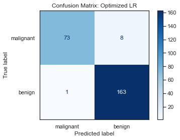

```python
lr_optm_prediction, lr_optm_report, lr_optm_cm =\
    predict_and_eval_classification_perf(lr_grid, X_test, y_test, [[1,0],['malignant','benign']], "Optimized LR")
```

Recall and F1-score are higher for Random Forest model so lets use that one.

##### What about Feature Importance from Optimized Random Forest?

This will likely be useful in getting adoption of the method. MDs understandably don't like black boxes

```python
importances = pd.DataFrame(grid.best_estimator_._final_estimator.feature_importances_,\
                           index=X_train.columns)#,\
                           #columns=['importance']).sort_values('importance',ascending=False)
```

```python
print(importances)
```

```
                         0
thickness         0.040474
uniformity_size   0.251562
uniformity_shape  0.229397
marg_adhesion     0.029741
se_size           0.045622
bare_nuclei       0.306280
bland_chromatin   0.061261
normal_nucleoli   0.030627
mitoses           0.005037
```

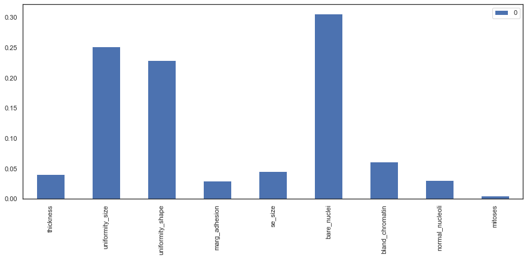

```python
importances.plot(kind="bar",figsize=(15,6))
plt.show()
```

### Check model performance with less features (could do RFE but lets start simply)

### Create a class to choose just the columns that I'm interested in so that I can wrap it in a pipeline

```python
from sklearn.base import BaseEstimator, TransformerMixin
```

```python
# Custom Transformer that extracts columns passed as argument
class FeatureChooser(BaseEstimator, TransformerMixin):
    '''A custom transformer that allows a subset of columns to be passed in a sklearn Pipeline'''

    def __init__(self, feature_names):
        '''Initialize'''
        self.feature_names = feature_names

    def fit(self, X, y = None):
        '''Fit to data method'''
        return self

    def transform(self, X, y = None):
        '''Applies transform to data'''
        return X[self.feature_names]
```

```python
cols_to_keep = ['uniformity_size', 'uniformity_shape', 'bare_nuclei']
```

```python
# Create the pipeline.
trimd_rf_pl_steps = [('trim_feats',FeatureChooser(cols_to_keep)),
                     ('KNN imputer', KNNImputer(n_neighbors=3, weights='distance')),
                ('robust scaler', RobustScaler()),
                ('rf', RandomForestClassifier(random_state=52))]
trimd_rf_pipeline = Pipeline(trimd_rf_pl_steps)
```

```python
grid_trimd = RandomizedSearchCV(trimd_rf_pipeline,param_distributions=random_grid,\
                          n_iter = 10, cv = 10, verbose=2, random_state=42,\
                          n_jobs = -1, scoring='recall')
```

```python
grid_trimd.fit(X_train,y_train)
```

```
Fitting 10 folds for each of 10 candidates, totalling 100 fits
```

```
[Parallel(n_jobs=-1)]: Using backend LokyBackend with 4 concurrent workers.
[Parallel(n_jobs=-1)]: Done  49 tasks      | elapsed:    6.0s
[Parallel(n_jobs=-1)]: Done 100 out of 100 | elapsed:   12.2s finished
```

```
RandomizedSearchCV(cv=10,
                   estimator=Pipeline(steps=[('trim_feats',
                                              FeatureChooser(feature_names=['uniformity_size',
                                                                            'uniformity_shape',
                                                                            'bare_nuclei'])),
                                             ('KNN imputer',
                                              KNNImputer(n_neighbors=3,
                                                         weights='distance')),
                                             ('robust scaler', RobustScaler()),
                                             ('rf',
                                              RandomForestClassifier(random_state=52))]),
                   n_jobs=-1,
                   param_distributions={'rf__max_depth': [1, 5, 9, 14, 18, 23,
                                                          27, 31, 36, 40, 45],
                                        'rf__max_features': ['log2', 'sqrt'],
                                        'rf__min_samples_split': [3, 5, 10, 15],
                                        'rf__n_estimators': [20, 40, 60, 80,
                                                             100, 120, 140, 160,
                                                             180, 200]},
                   random_state=42, scoring='recall', verbose=2)
```

```python
print("score = %3.2f" %(grid_trimd.score(X_test,y_test)))
```

```
score = 0.95
```

```python
print(grid_trimd.best_params_)
```

```
{'rf__n_estimators': 40, 'rf__min_samples_split': 5, 'rf__max_features': 'log2', 'rf__max_depth': 18}
```

```python
print(grid_trimd.best_estimator_)
```

```
Pipeline(steps=[('trim_feats',
                 FeatureChooser(feature_names=['uniformity_size',
                                               'uniformity_shape',
                                               'bare_nuclei'])),
                ('KNN imputer', KNNImputer(n_neighbors=3, weights='distance')),
                ('robust scaler', RobustScaler()),
                ('rf',
                 RandomForestClassifier(max_depth=18, max_features='log2',
                                        min_samples_split=5, n_estimators=40,
                                        random_state=52))])
```

```
              precision    recall  f1-score   support

           0       0.98      0.96      0.97       164
           1       0.93      0.95      0.94        81

    accuracy                           0.96       245
   macro avg       0.95      0.96      0.95       245
weighted avg       0.96      0.96      0.96       245
```

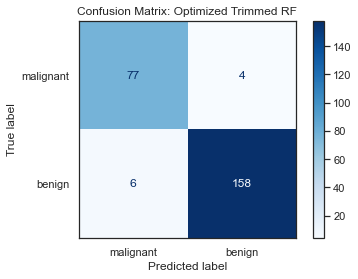

```python
trim_rf_optm_prediction, trim_rf_optm_report, trim_rf_optm_cm =\
    predict_and_eval_classification_perf(grid_trimd, X_test, y_test, [[1,0],['malignant','benign']], "Optimized Trimmed RF")
```

```python
# Make a ROC curve to assess global performance of model
from sklearn.metrics import plot_roc_curve
```

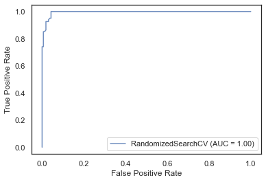

```python
# Make ROC curve
ax = plt.gca()
grid_trimd_disp = plot_roc_curve(grid_trimd, X_test, y_test, ax=ax, alpha=0.8)
#svc_disp.plot(ax=ax, alpha=0.8)
plt.show()
```

### You could probably create a model that detects 100% of the malignants with a low level of false positives (~0.1) using only 3 features

# Summary of all the models

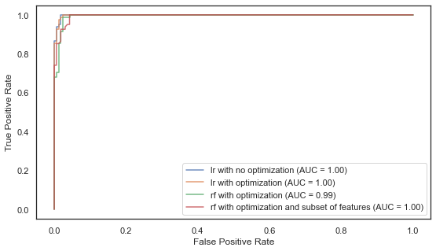

```python
plt.figure(figsize=(9,5))
ax = plt.gca()
plot_roc_curve(pipeline, X_test, y_test, ax=ax, alpha=0.8, name="lr with no optimization")
plot_roc_curve(lr_grid, X_test, y_test, ax=ax, alpha=0.8, name="lr with optimization")
plot_roc_curve(grid, X_test, y_test, ax=ax, alpha=0.8, name="rf with optimization")
plot_roc_curve(grid_trimd, X_test, y_test, ax=ax, alpha=0.8, name="rf with optimization and subset of features")

plt.show()
```